# Super Store Sales Data Analysis Assignment by Sidrah Abdullah

2022-05-16

## Introduction

This document is an EDA assignment, courtesy of IEC Data Analytics course. The dataset used in this document is EU Superstore data set. It provides a description on sales, profit and discount of each product in each order. Although the EDA could cover a lot of options, I have covered some basic analysis. Here you go!~

## Exploratory Data Analysis

### Importing Required Libraries

The first step is to import all the required libraries required for the project.

```r
library(readxl)
library(naniar)
library(dplyr)
library(tidyverse)
```

```r
library(ggplot2)
library(grid)
library(rworldmap)
library(plotly)
library(gridExtra)
```

### Read Dataset and Convert it into Dataframe

Next, we will import the EU Superstore data set and convert it into dataframe.

```r
df_superStore<-read_excel('C:/Users/Sidra Abdullah/Desktop/EUSuperstore.xls')

df_superStore <- data.frame(df_superStore)
```

### Look at the Data Summary

After that, we will take a look at our data to check what it looks like. You can simply use the View() function in R, or analyze it using the code given below:

```r
head(df_superStore)
```

```
##   Row.ID        Order.ID Order.Date  Ship.Date      Ship.Mode Customer.ID
## 1      1 ES-2018-1311038 2018-02-07 2018-02-11 Standard Class    AS-10045
## 2      2 ES-2018-1311038 2018-02-07 2018-02-11 Standard Class    AS-10045
## 3      3 ES-2018-1311038 2018-02-07 2018-02-11 Standard Class    AS-10045
## 4      4 ES-2018-1311038 2018-02-07 2018-02-11 Standard Class    AS-10045
## 5      5 ES-2018-1311038 2018-02-07 2018-02-11 Standard Class    AS-10045
## 6      6 ES-2018-1311038 2018-02-07 2018-02-11 Standard Class    AS-10045
##    Customer.Name   Segment  City   State        Country Region      Product.ID
## 1 Aaron Smayling Corporate Leeds England United Kingdom  North OFF-ST-10000988
## 2 Aaron Smayling Corporate Leeds England United Kingdom  North TEC-AC-10004144
## 3 Aaron Smayling Corporate Leeds England United Kingdom  North OFF-LA-10001915
## 4 Aaron Smayling Corporate Leeds England United Kingdom  North OFF-ST-10004550
## 5 Aaron Smayling Corporate Leeds England United Kingdom  North TEC-AC-10004068
## 6 Aaron Smayling Corporate Leeds England United Kingdom  North OFF-ST-10002271
##          Category Sub.Category                               Product.Name
## 1 Office Supplies      Storage                     Fellowes Folders, Blue
## 2      Technology  Accessories          SanDisk Numeric Keypad, Bluetooth
## 3 Office Supplies       Labels Avery Legal Exhibit Labels, 5000 Label Set
## 4 Office Supplies      Storage               Fellowes Folders, Wire Frame
## 5      Technology  Accessories                   Memorex Memory Card, USB
## 6 Office Supplies      Storage                Rogers Shelving, Wire Frame
##    Sales Quantity Discount Profit
## 1  79.20        3        0  39.60
## 2 388.92        7        0   0.00
## 3  35.19        3        0  16.11
## 4  50.94        2        0  13.20
## 5 307.44        3        0  73.71
## 6 122.40        2        0  37.92
```

```r
dim(df_superStore)
```

```
## [1] 10000    20
```

```r
summary(df_superStore)
```

```
##      Row.ID        Order.ID           Order.Date
##  Min.   :    1   Length:10000       Min.   :2015-01-01 00:00:00
##  1st Qu.: 2501   Class :character   1st Qu.:2016-06-30 00:00:00
##  Median : 5000   Mode  :character   Median :2017-07-09 00:00:00
##  Mean   : 5000                      Mean   :2017-05-14 15:05:45
##  3rd Qu.: 7500                      3rd Qu.:2018-06-03 00:00:00
##  Max.   :10000                      Max.   :2018-12-31 00:00:00
##    Ship.Date                    Ship.Mode         Customer.ID
##  Min.   :2015-01-05 00:00:00   Length:10000       Length:10000
##  1st Qu.:2016-07-05 00:00:00   Class :character   Class :character
##  Median :2017-07-11 00:00:00   Mode  :character   Mode  :character
##  Mean   :2017-05-18 15:14:24
##  3rd Qu.:2018-06-06 00:00:00
##  Max.   :2019-01-05 00:00:00
##  Customer.Name        Segment              City              State
##  Length:10000       Length:10000       Length:10000       Length:10000
##  Class :character   Class :character   Class :character   Class :character
##  Mode  :character   Mode  :character   Mode  :character   Mode  :character
##
##
##
##    Country             Region           Product.ID          Category
##  Length:10000       Length:10000       Length:10000       Length:10000
##  Class :character   Class :character   Class :character   Class :character
##  Mode  :character   Mode  :character   Mode  :character   Mode  :character
##
##
##
##  Sub.Category       Product.Name           Sales             Quantity
##  Length:10000       Length:10000       Min.   :   2.955   Min.   : 1.000
##  Class :character   Class :character   1st Qu.:  49.462   1st Qu.: 2.000
##  Mode  :character   Mode  :character   Median : 119.355   Median : 3.000
##                                        Mean   : 293.809   Mean   : 3.777
##                                        3rd Qu.: 320.709   3rd Qu.: 5.000
##                                        Max.   :7958.580   Max.   :14.000
##     Discount          Profit
##  Min.   :0.0000   Min.   :-3059.82
##  1st Qu.:0.0000   1st Qu.:    1.32
##  Median :0.0000   Median :   14.22
##  Mean   :0.1031   Mean   :   37.28
##  3rd Qu.:0.1000   3rd Qu.:   48.51
##  Max.   :0.8500   Max.   : 3979.08
```

```r
#cor(df_superStore)
```

### Time for Some Data Cleaning

Data Cleaning is an important step! In this step, we usually look out for missing, Null and duplicated values. Let’s start with these operations:

```r
summary(is.na(df_superStore))
```

```
##    Row.ID         Order.ID       Order.Date      Ship.Date
##  Mode :logical   Mode :logical   Mode :logical   Mode :logical
##  FALSE:10000     FALSE:10000     FALSE:10000     FALSE:10000
##  Ship.Mode       Customer.ID     Customer.Name    Segment
##  Mode :logical   Mode :logical   Mode :logical   Mode :logical
##  FALSE:10000     FALSE:10000     FALSE:10000     FALSE:10000
##     City           State          Country          Region
##  Mode :logical   Mode :logical   Mode :logical   Mode :logical
##  FALSE:10000     FALSE:10000     FALSE:10000     FALSE:10000
##  Product.ID       Category       Sub.Category    Product.Name
##  Mode :logical   Mode :logical   Mode :logical   Mode :logical
##  FALSE:10000     FALSE:10000     FALSE:10000     FALSE:10000
##    Sales          Quantity        Discount         Profit
##  Mode :logical   Mode :logical   Mode :logical   Mode :logical
##  FALSE:10000     FALSE:10000     FALSE:10000     FALSE:10000
```

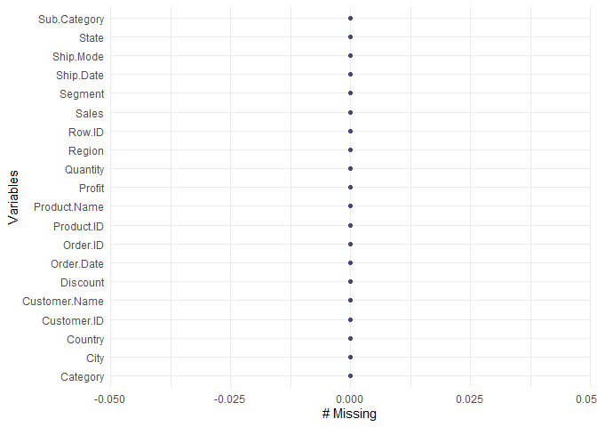

```r
gg_miss_var(df_superStore)
```

```r
miss_var_summary(df_superStore)
```

```
## # A tibble: 20 x 3
##    variable      n_miss pct_miss
##    <chr>          <int>    <dbl>
##  1 Row.ID             0        0
##  2 Order.ID           0        0
##  3 Order.Date         0        0
##  4 Ship.Date          0        0
##  5 Ship.Mode          0        0
##  6 Customer.ID        0        0
##  7 Customer.Name      0        0
##  8 Segment            0        0
##  9 City               0        0
## 10 State              0        0
## 11 Country            0        0
## 12 Region             0        0
## 13 Product.ID         0        0
## 14 Category           0        0
## 15 Sub.Category       0        0
## 16 Product.Name       0        0
## 17 Sales              0        0
## 18 Quantity           0        0
## 19 Discount           0        0
## 20 Profit             0        0
```

For duplicate values, there are multiple ways to check it. These ways are given below:

```r
which(duplicated(df_superStore))
```

```
## integer(0)
```

```r
sum(duplicated(df_superStore))
```

```
## [1] 0
```

```r
df_superStore |> distinct() |> nrow()
```

```
## [1] 10000
```

However, these value shows repeated rows (if any). If we want to check particularly for repeated order details, then we will go for the process given below. Since each row in data represents a unique product for unique order, we will first make it a composite primary key.

After that, we have counted only those unique PKs if their value is greater than 1.

Lastly, we applied inner join on both to find the matched entries.

```r
df_superStore |>
  mutate(key = paste(Order.ID, Product.ID)) -> df_superStore_key

df_superStore_key |>
  count(key) |>
  filter(n>1) -> df_key_duplicates

df_superStore_key |>
  inner_join(df_key_duplicates |>
               select(key)) -> repeatedEntries
```

But, we must keep in mind that there will always be 3-5% inaccuracy in data, and there is no point in wasting time on dealing the values case-by-case. Hence, we have ignored these inaccuracies.

### Exploratory Data Analysis

```r
df_superStore |>
  group_by(Category) |>
  summarise(across(c(Sales, Quantity, Profit), list(sum = sum))) -> eda1
```

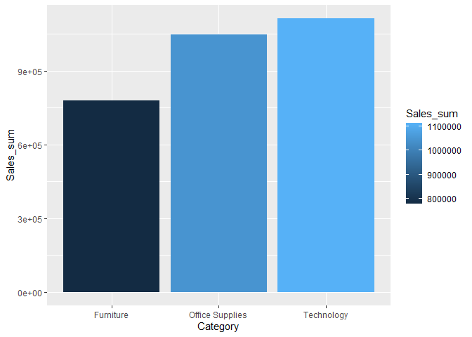

```r
  p <- ggplot(eda1, aes(x = Category, y = Sales_sum, fill = Sales_sum) ) +
  geom_bar(stat = "identity")
  p
```

Next, we checked the profit margin on each sub-category, and created its stacked chart to view Sales and Profit Margin together.

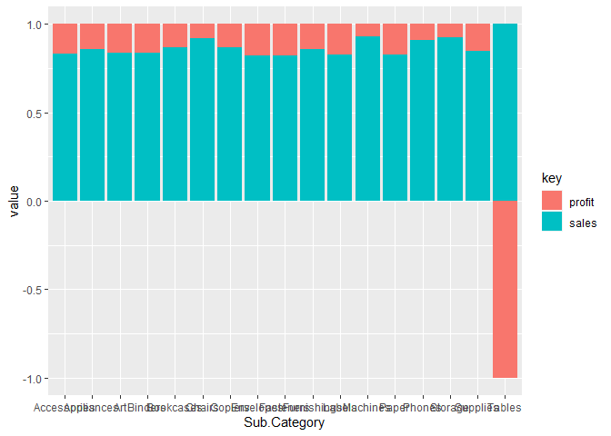

```r
df_superStore |>
  group_by(Sub.Category) |>
  summarise(sales = sum(Sales),
            profit = sum(Profit)) |>
  mutate(cost = sales - profit) -> df_superStore_subCategorySales

df_superStore_subCategorySales |>
  mutate(margin = profit / sales) -> df_superStore_subCategorySales

pivot_longer(df_superStore_subCategorySales,
             sales:profit,
             names_to = "key",
             values_to = "value") -> df_superStore_subCategorySales_long
options(scipen = 999)
p2 <- ggplot(df_superStore_subCategorySales_long,
         aes(x = Sub.Category, y = value, fill = key)) +
    geom_bar(stat = "identity", position = "fill")

p2
```

From this chart, we can see that the sub-category tables has the least amount of profit.

```r
df_superStore |>
  mutate(month = lubridate::month(Order.Date, label=TRUE),
         weekDay = lubridate::wday(Order.Date, label = TRUE)) |>
  group_by(month, weekDay) |>
  summarise(nTransactions = n_distinct(Order.ID)) -> transactions_month_day
```

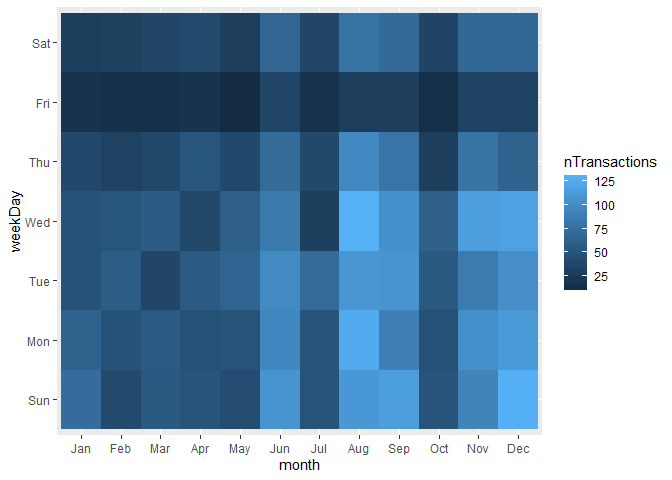

```r
p3 <- ggplot(transactions_month_day,
         aes(x = month, fill = nTransactions, y = weekDay)) +
    geom_tile()
p3
```

From this graph, we can see that our best sale day is Wednesday. And the month of December seems to have the most sales. In fact, the second half of the year has better sales as compared to the first half.

Lastly, we checked the profit margin country-wise over the map. It was a bit tricky to create the map, so here is the complete process:

1. Get the world map.
2. Define countries in the Europe that you wish to included.
3. Select the indexes of the states.
4. Define coordinates using latitude and longitude.
5. Get the value you wish to display on the chart.
6. Store it in the data frame of European Union Table.
7. Plot using geom polygon

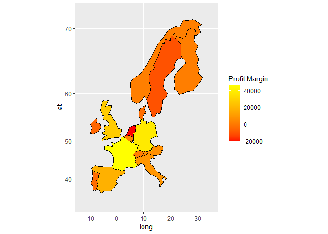

```r
# Step 1
worldMap <- getMap()

# Step 2
europeanUnion <- c("Austria","Belgium", "Denmark","Finland","France",
                   "Germany","Ireland","Italy","Netherlands","Norway",
                   "Portugal", "Spain",
                   "Sweden","Switzerland", "United Kingdom")

# Step 3
indEU <- which(worldMap$NAME%in%europeanUnion)
View(indEU)

# Step 4
europeCoords <- lapply(indEU, function(i){
  df <- data.frame(worldMap@polygons[[i]]@Polygons[[1]]@coords)
  df$region =as.character(worldMap$NAME[i])
  colnames(df) <- list("long", "lat", "region")
  return(df)
})

europeCoords <- do.call("rbind", europeCoords)

# Step 5
df_superStore$profitMargin <- (df_superStore$Profit / df_superStore$Sales ) * 100
df_superStore$profitMargin <- round(df_superStore$profitMargin, 1)
df_superStore |>
  group_by(Country) |>
  summarise(profit = sum(profitMargin)) -> value
View(value)

#Step 6
europeanUnionTable <- data.frame(country = europeanUnion, value = value$profit)
europeCoords$value <- europeanUnionTable$value[match(europeCoords$region,europeanUnionTable$country)]

# Step 7
P <- ggplot() + geom_polygon(data = europeCoords,
                        aes(x = long, y = lat, group = region, fill = value),
                        colour = "black", size = 0.1) +
  coord_map(xlim = c(-13, 35),  ylim = c(32, 71))

P <- P + scale_fill_gradient(name = "Profit Margin", low = "#FF0000FF", high = "#FFFF00FF", na.value = "grey50")

P
```

### RFM Analysis on the Superstore Dataset

For RFM Analysis, we need to calculate total sales (quantity * unit price), convert invoice data into date format and total number of transactions per customer. Let’s get started.

```r
df_superStore$total <- df_superStore$Quantity * df_superStore$Sales
df_superStore$invoiceDate <- as.Date(df_superStore$Order.Date, "%Y-%m-%d")
head(df_superStore)
```

```
##   Row.ID        Order.ID Order.Date  Ship.Date      Ship.Mode Customer.ID
## 1      1 ES-2018-1311038 2018-02-07 2018-02-11 Standard Class    AS-10045
## 2      2 ES-2018-1311038 2018-02-07 2018-02-11 Standard Class    AS-10045
## 3      3 ES-2018-1311038 2018-02-07 2018-02-11 Standard Class    AS-10045
## 4      4 ES-2018-1311038 2018-02-07 2018-02-11 Standard Class    AS-10045
## 5      5 ES-2018-1311038 2018-02-07 2018-02-11 Standard Class    AS-10045
## 6      6 ES-2018-1311038 2018-02-07 2018-02-11 Standard Class    AS-10045
##    Customer.Name   Segment  City   State        Country Region      Product.ID
## 1 Aaron Smayling Corporate Leeds England United Kingdom  North OFF-ST-10000988
## 2 Aaron Smayling Corporate Leeds England United Kingdom  North TEC-AC-10004144
## 3 Aaron Smayling Corporate Leeds England United Kingdom  North OFF-LA-10001915
## 4 Aaron Smayling Corporate Leeds England United Kingdom  North OFF-ST-10004550
## 5 Aaron Smayling Corporate Leeds England United Kingdom  North TEC-AC-10004068
## 6 Aaron Smayling Corporate Leeds England United Kingdom  North OFF-ST-10002271
##          Category Sub.Category                               Product.Name
## 1 Office Supplies      Storage                     Fellowes Folders, Blue
## 2      Technology  Accessories          SanDisk Numeric Keypad, Bluetooth
## 3 Office Supplies       Labels Avery Legal Exhibit Labels, 5000 Label Set
## 4 Office Supplies      Storage               Fellowes Folders, Wire Frame
## 5      Technology  Accessories                   Memorex Memory Card, USB
## 6 Office Supplies      Storage                Rogers Shelving, Wire Frame
##    Sales Quantity Discount Profit profitMargin   total invoiceDate
## 1  79.20        3        0  39.60         50.0  237.60  2018-02-07
## 2 388.92        7        0   0.00          0.0 2722.44  2018-02-07
## 3  35.19        3        0  16.11         45.8  105.57  2018-02-07
## 4  50.94        2        0  13.20         25.9  101.88  2018-02-07
## 5 307.44        3        0  73.71         24.0  922.32  2018-02-07
## 6 122.40        2        0  37.92         31.0  244.80  2018-02-07
```

```r
summary(df_superStore)
```

```
##      Row.ID        Order.ID           Order.Date
##  Min.   :    1   Length:10000       Min.   :2015-01-01 00:00:00
##  1st Qu.: 2501   Class :character   1st Qu.:2016-06-30 00:00:00
##  Median : 5000   Mode  :character   Median :2017-07-09 00:00:00
##  Mean   : 5000                      Mean   :2017-05-14 15:05:45
##  3rd Qu.: 7500                      3rd Qu.:2018-06-03 00:00:00
##  Max.   :10000                      Max.   :2018-12-31 00:00:00
##    Ship.Date                    Ship.Mode         Customer.ID
##  Min.   :2015-01-05 00:00:00   Length:10000       Length:10000
##  1st Qu.:2016-07-05 00:00:00   Class :character   Class :character
##  Median :2017-07-11 00:00:00   Mode  :character   Mode  :character
##  Mean   :2017-05-18 15:14:24
##  3rd Qu.:2018-06-06 00:00:00
##  Max.   :2019-01-05 00:00:00
##  Customer.Name        Segment              City              State
##  Length:10000       Length:10000       Length:10000       Length:10000
##  Class :character   Class :character   Class :character   Class :character
##  Mode  :character   Mode  :character   Mode  :character   Mode  :character
##
##
##
##    Country             Region           Product.ID          Category
##  Length:10000       Length:10000       Length:10000       Length:10000
##  Class :character   Class :character   Class :character   Class :character
##  Mode  :character   Mode  :character   Mode  :character   Mode  :character
##
##
##
##  Sub.Category       Product.Name           Sales             Quantity
##  Length:10000       Length:10000       Min.   :   2.955   Min.   : 1.000
##  Class :character   Class :character   1st Qu.:  49.462   1st Qu.: 2.000
##  Mode  :character   Mode  :character   Median : 119.355   Median : 3.000
##                                        Mean   : 293.809   Mean   : 3.777
##                                        3rd Qu.: 320.709   3rd Qu.: 5.000
##                                        Max.   :7958.580   Max.   :14.000
##     Discount          Profit          profitMargin         total
##  Min.   :0.0000   Min.   :-3059.82   Min.   :-473.40   Min.   :     2.96
##  1st Qu.:0.0000   1st Qu.:    1.32   1st Qu.:   2.00   1st Qu.:   128.99
##  Median :0.0000   Median :   14.22   Median :  17.80   Median :   423.48
##  Mean   :0.1031   Mean   :   37.28   Mean   :  11.02   Mean   :  1479.36
##  3rd Qu.:0.1000   3rd Qu.:   48.51   3rd Qu.:  33.00   3rd Qu.:  1290.92
##  Max.   :0.8500   Max.   : 3979.08   Max.   :  50.00   Max.   :111420.12
##   invoiceDate
##  Min.   :2015-01-01
##  1st Qu.:2016-06-30
##  Median :2017-07-09
##  Mean   :2017-05-14
##  3rd Qu.:2018-06-03
##  Max.   :2018-12-31
```

We now calculate the following values:

Recency : difference between the analysis date and the most recent date, that the customer has shopped in the store. The analysis date here has been taken as the maximum date available for the variable InvoiceDate.

Frequency : Number of transactions performed by every customer.

Monetary: Total money spent by every customer in the store.

```r
analysis_date <- max(df_superStore$invoiceDate)
rfm_df <- df_superStore |>
  group_by(Customer.ID) |>
  summarise(Recency = as.numeric(analysis_date- max(invoiceDate)),
            Frequency = n(),
            Monetary = sum(total))
nrow(rfm_df)
```

```
## [1] 795
```

We can now plot the density plots to understand the distribution of the three quantities calculated here.

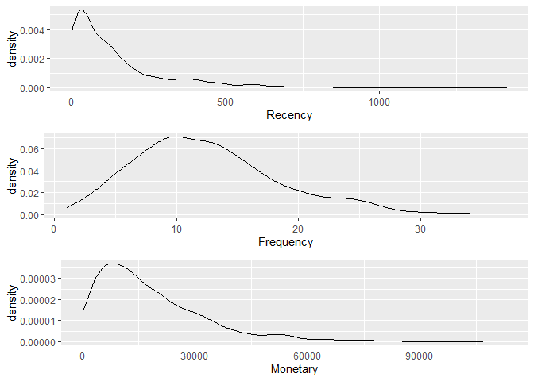

```r
r <- ggplot(rfm_df) +geom_density(aes(x= Recency))
f <- ggplot(rfm_df) +geom_density(aes(x = Frequency))
m <- ggplot(rfm_df) +geom_density(aes(x = Monetary))
grid.arrange(r, f, m, nrow = 3)
```

### Calculate the RFM Score

We can see that all the quantities calculated here — Recency, frequency and monetary has different ranges. We first convert these quantities to scores based on their quartiles. For this, we start with looking at the summary of these values.

```r
summary(rfm_df)
```

```
##  Customer.ID           Recency       Frequency        Monetary
##  Length:795         Min.   :   0   Min.   : 1.00   Min.   :    23.4
##  Class :character   1st Qu.:  30   1st Qu.: 8.00   1st Qu.:  7376.1
##  Mode  :character   Median :  91   Median :12.00   Median : 14093.0
##                     Mean   : 145   Mean   :12.58   Mean   : 18608.2
##                     3rd Qu.: 188   3rd Qu.:16.00   3rd Qu.: 25382.7
##                     Max.   :1412   Max.   :37.00   Max.   :113108.8
```

```r
rfm_df$R_score <- 0
rfm_df$R_score[rfm_df$Recency >= 1412] <- 1
rfm_df$R_score[rfm_df$Recency >= 188 & rfm_df$Recency <1412] <- 2
rfm_df$R_score[rfm_df$Recency >= 145 & rfm_df$Recency <188] <- 3
rfm_df$R_score[rfm_df$Recency >= 91 & rfm_df$Recency <145] <- 4
rfm_df$R_score[rfm_df$Recency < 30] <- 5
rfm_df$F_score<- 0
rfm_df$F_score[rfm_df$Frequency >=37] <- 5
rfm_df$F_score[rfm_df$Frequency <37 & rfm_df$Frequency >= 16] <- 4
rfm_df$F_score[rfm_df$Frequency <16 & rfm_df$Frequency >= 12] <- 3
rfm_df$F_score[rfm_df$Frequency <12 & rfm_df$Frequency >= 8] <- 2
rfm_df$F_score[rfm_df$Frequency <8] <- 1
rfm_df$M_score <- 0
rfm_df$M_score[rfm_df$Monetary >= 113108.8 ] <- 5
rfm_df$M_score[rfm_df$Monetary < 113108.8  & rfm_df$Monetary >= 25382.7 ] <- 4
rfm_df$M_score[rfm_df$Monetary >= 25382.7 & rfm_df$Monetary < 18608.2 ] <- 3
rfm_df$M_score[rfm_df$Monetary >= 18608.2 & rfm_df$Monetary < 14093.0 ] <- 2
rfm_df$M_score[rfm_df$Monetary <7376.1] <- 1
```

```r
rfm_df <- rfm_df %>% mutate(RFM_score = 100 *R_score +10 * F_score + M_score)
View(rfm_df)
```

```r
rfm_df$Segment <- "0"
rfm_df$Segment[which(rfm_df$RFM_score %in% c(514, 521, 524, 534, 541, 544  ))] <-"Loyalists"
rfm_df$Segment[which(rfm_df$RFM_score %in% c(324, 330, 334, 340, 341, 344, 510, 511, 520, 530, 540))] <- "Potential Loyalists"
rfm_df$Segment[which(rfm_df$RFM_score %in% c(234, 240, 244, 310, 311, 320, 321, 324, 330, 334))] <- "Promising"
rfm_df$Segment[which(rfm_df$RFM_score %in% c(221 ,224,234, 240, 244 ))] <- "Hesitant"
rfm_df$Segment[which(rfm_df$RFM_score %in% c(210, 211, 214, 220, 221, 224, 230))] <- "Need attention"
rfm_df$Segment[which(rfm_df$RFM_score %in% c(10, 11, 14, 20, 21, 24, 30, 31, 34, 40, 44, 111))] <-"Detractors"
```

Now let’s see how may customers fall into each segment.

```r
table(rfm_df$Segment)
```

```
##
##                   0          Detractors            Hesitant           Loyalists
##                 158                 202                  36                  67
##      Need attention Potential Loyalists           Promising
##                 161                 130                  41
```

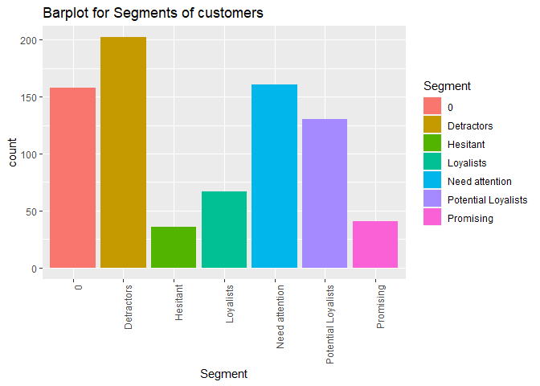

```r
ggplot(rfm_df) + geom_bar(aes(x = Segment, fill = Segment))+theme(axis.text.x=element_text(angle=90,hjust=1)) +labs(title = "Barplot for Segments of customers")
```

This concludes the RFM analysis for customer segmentation. Now we can move on to our next step, which is to calculate CLV.

Thank you for reading till the end!~